# Introduction to Data Processing and Data Visualization

Recitation 6

Ozancan Ozdemir

Department of Statistics, METU, ozancan@metu.edu.tr

## Data Visualization with Flourish

Flourish is an interactive data visualization tool used for developing an efficient story using visuals in 2016. It’s free and simple to use. Flourish is easy enough for everyone to use, unlike other sophisticated solutions designed for data experts. It’s combination of customizability and usability offers a nice middle ground between the charts automatically generated by Excel or Google Sheets and coding your own visualization with JavaScript, Python, or R. It is also adaptable and refined enough to be used in projects for a professional newsroom. That’s why it is also in [**Google Journalist Studio.**](https://journaliststudio.google.com/). Additionally, it has several themes so you can quickly and easily construct a powerful dynamic data visual to embed on any website.

You can examine how the Flourish was used efficiently from [BBC COVID-19 Data Tracker.](https://www.bbc.com/news/world-51235105) Also, the first data journal of Turkey, as far as we know, [VeriPie](http://www.veripie.com.tr/) uses Flourish to prepare their visuals.

A visual creating process can be done quickly in Flourish. Of course, your data should be well prepared. (i.e no quality problem.)

- **Sign up your free account**.

Open [flourish.studio](https://flourish.studio/) and sign up for free. You can sign in with Google or enter your name and email to create an account. Answer a few simple questions and click **Submit.**

[figure not shown]

- **First Meeting with Flourish**

[figure not shown]

Investigate the Flourish interface using **column chart.**

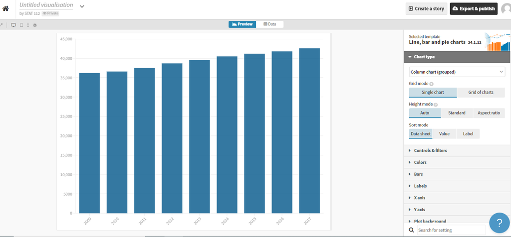

The visualization editor has **four main parts**:

- **Preview tab** – this is where you can see what your project will look like when it’s published.

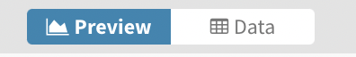

- **Data tab** – this is where you should [upload your own data.](https://help.flourish.studio/article/12-adding-data-to-a-template) If you edit or replace any information within these cells, your visualization will **instantly** reflect these changes.

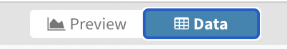

  Some **Data tabs** have more than one data sheet. If you are not sure how your data should be structured, or what each sheet affects in the visualization, you can read the [template-specific help docs](https://help.flourish.studio/). You can also access them through the chat symbol in the bottom right-hand corner of every page!
- **Column bindings** – which let you control **which columns of data are used** in the visualization, and in what way.

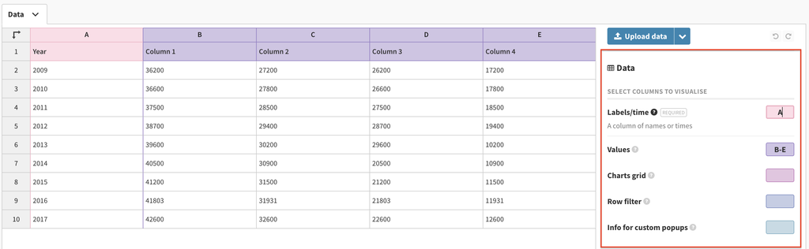

  **Preview settings panel** – which lets you change the **look and feel** of the visualization. The settings at the top of the page are usually template-specific, whereas the bottom options ( *Layout*, *Header*, *Footer*, *Accessibility*) work in the same way in all templates.

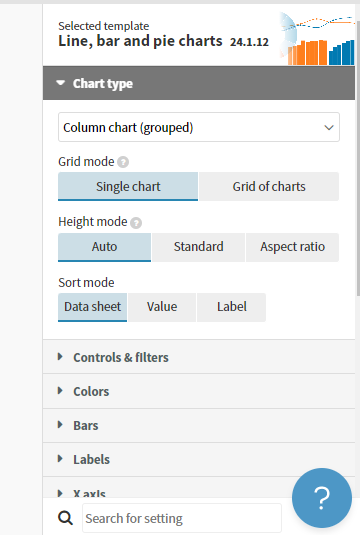

After this introduction part, we can start our first project which covers creating and customizing the visuals. Start with a column chart.

Select Column Chart from Template Page, and then click data to open the data tab.

After that click on the preview page. You see that your first visual is done. Yeeeeeyy!

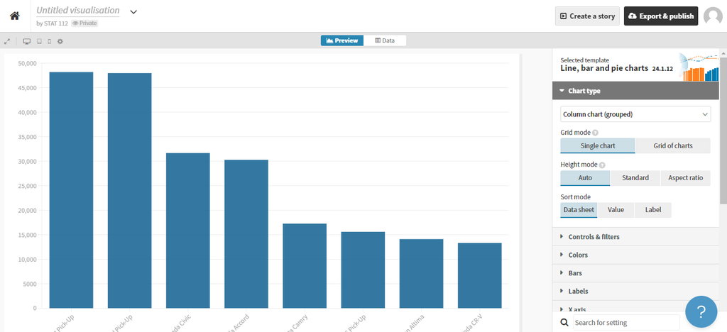

Now, customize the appearance of your plot using preview setting panel.

- Chart Type : You can change the type of the chart you are working.
- Colors: You can fill your visual with a color or change the existing color.
- Bar: It is a special option for the column chart, you can set the appearance of the bar
- X axis-Y axis: This menu helps you to customize the axis of your plot.
- Plot background: You can fill your visual background with a color or an image.
- Number and Date Formatting: You can customize the display of the number and date in your plot.
- Legend: It arranges the legend box on the plot, if it appears.
- Layout: You can change the font of your visual.
- Header-Footer: You can add title, subtitle, caption and picture to your visual.

As you remember from the previous hour, we do not want the readers to turn their head while looking at the plot. Thus, change the chart type from column chart to bar chart.

Then, sort your data based on the value.

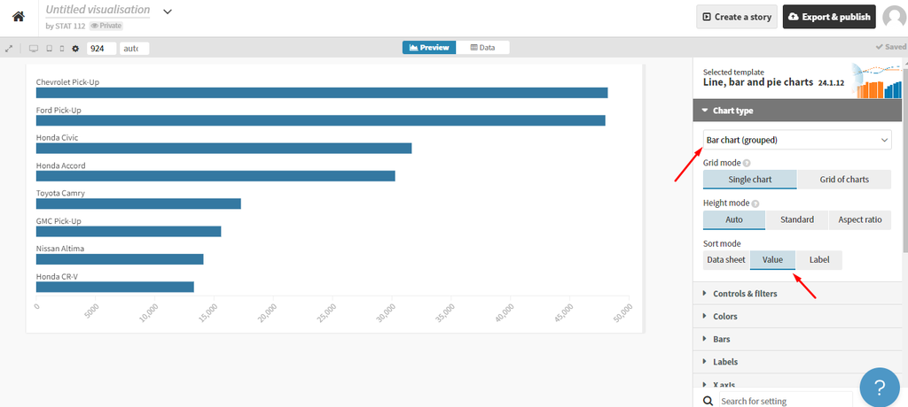

Make your bar bigger by increasing bar height

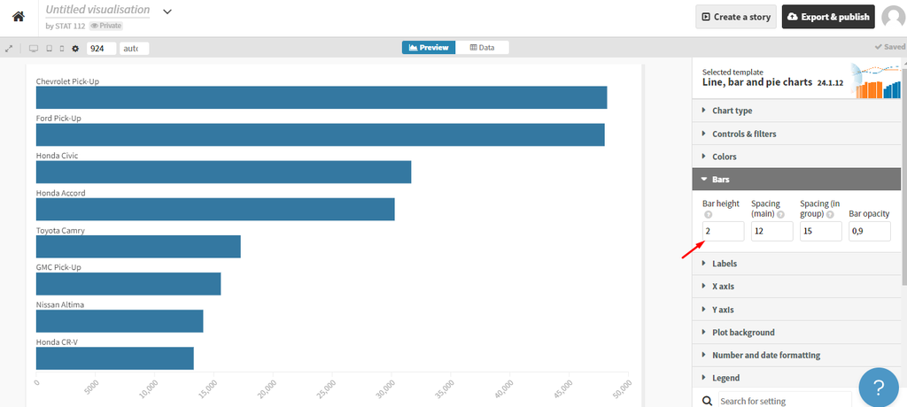

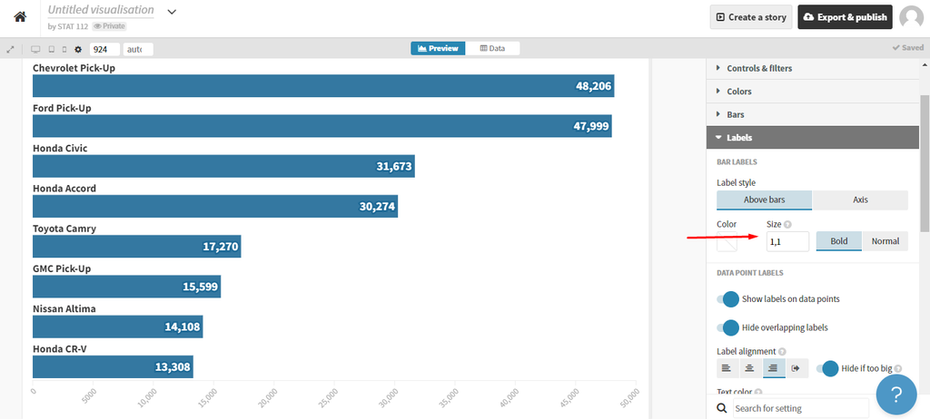

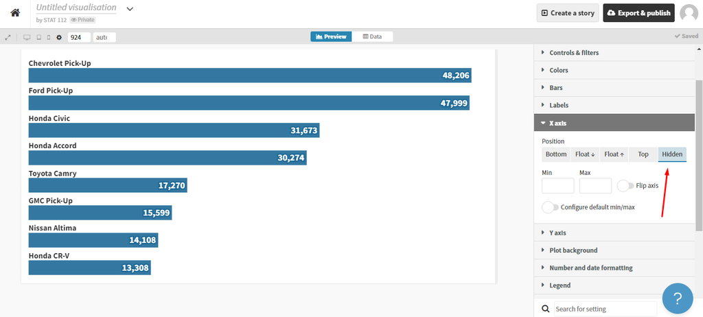

Change the background of your plot from plot background.

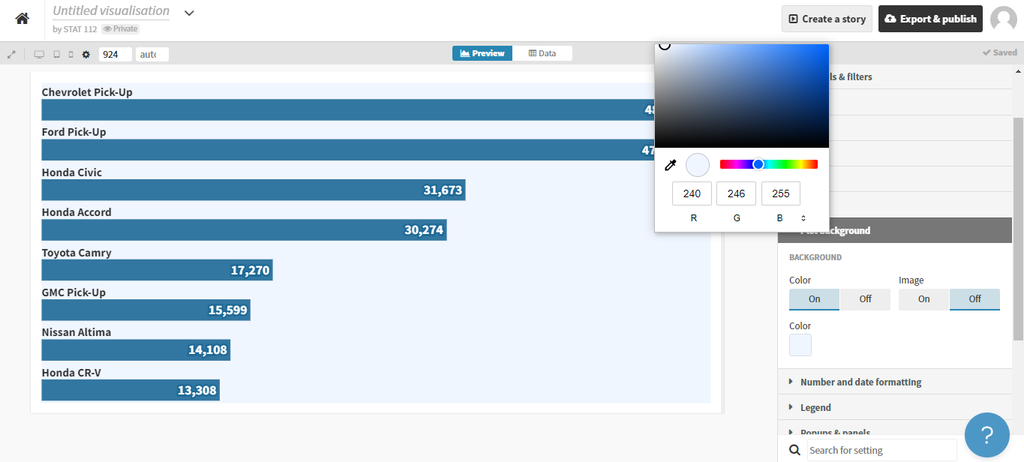

You can add title and subtitle from header bar. You can customize them by activating styling option.

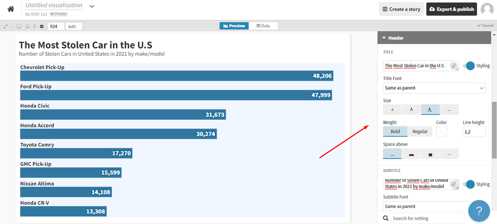

Then, add source to bottom of the plot from footer panel. You can also add logo from the logo option under footer panel.

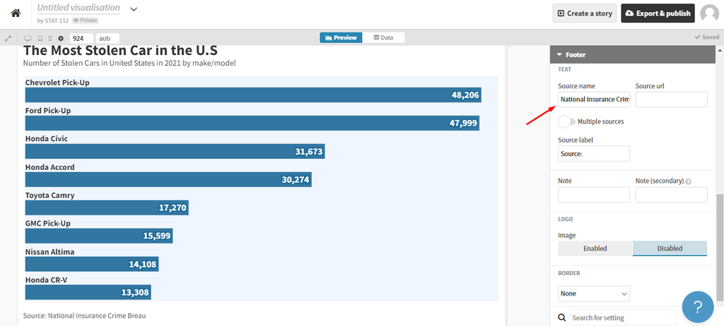

Here is the plot!

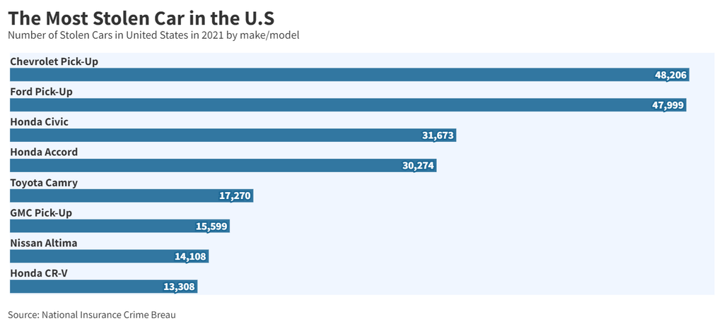

[figure not shown]

[figure not shown]

So, you have created the your first basic plot. Let’s continue with the better one.

Now, it is your turn!

#### Exercise 1

Go to template page and open **Bar Chart Race**

Display the data, and remove the columns except the first three ones.

Import your **gapminder_wider.xlsx**. Note that instead of uploading data, please select upload and merge the data.

Merge existing data and imported data by column name.

Change the data type from text to number.

Remove the countries with no observation.

Create your bar chart.

[figure not shown]

**Note:** If the data structure of the visual has an image column, you can add your own images instead of Flourish figures. You will just copy the link of your picture which ends with .png or .jpeg and paste the image column.

#### Exercise 2

Consider **Fish.xlsx** data. The data denotes the properties of 7 common different fish species in fish market sales. The properties are

- Species
- Weight
- Length 1
- Length 2
- Length 3
- Height
- Width

  Draw a chart which answers the given research question.

What is the relationship between Height and Length1 by the weight and species of the fishes?

**Sources**

- [Flourish Help](https://help.flourish.studio/article/9-creating-a-visualization)
- [Google Flourish Lesson](https://newsinitiative.withgoogle.com/training/lessons?tool=Flourish&image=flourish)

## Introduction to Numpy

Numpy is an open source Python library that’s used in almost every field of science and engineering. In this course, we will implement Python codes on Google Colab, which is a free Jupyter notebook environment that requires no setup and runs entirely in the cloud. With Colaboratory you can write and execute code, save and share your analyses, and access powerful computing resources, all for free from your browser.

Please go to https://colab.research.google.com/

To open a new notebook, please click on open a new notebook.

[figure not shown]

You can add text or code chunk by clicking on either code or text.

[figure not shown]

The following picture shows how to write a text in Google Colab.

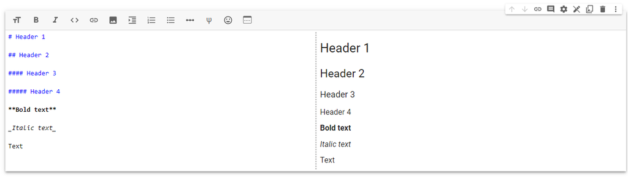

You can add code chunk by clicking on code option as stated above. You can execute your code either clicking on play button or pressing Ctrl+Enter simultaneously on your keyboard.

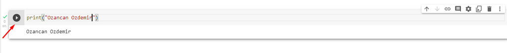

You can download your notebook file as a Jupyter Notebook File (.ipynb) or Python Script (.py) from File menu.

[figure not shown]

Now, please download “STAT_112_Recitation 6_Part_II.ipynb” from ODTUClass and open the Colab window.